# Assessing Performance - Polynomial Regression

In this lesson, we will compare different regression models in order to assess which model fits best. We will be using polynomial regression as a means to examine this topic.

Learning objectives:

- Writing a function to take an an array and a degree and return an data frame where each column is the array to a polynomial value up to the total degree;
- Using a plotting tool (e.g. matplotlib) to visualize polynomial regressions;
- Using a plotting tool (e.g. matplotlib) to visualize the same polynomial degree on different subsets of the data;
- Using a validation set to select a polynomial degree;
- Assessing the final fit using test data.

We will continue to use the House data from previous notebooks.

```python
import pandas as pd
import numpy as np
from sklearn import linear_model
import matplotlib.pyplot as plt
```

```python
### Importing data:
dtype_dict = {'bathrooms':float, 'waterfront':int, 'sqft_above':int, 'sqft_living15':float, 'grade':int,
              'yr_renovated':int, 'price':float, 'bedrooms':float, 'zipcode':str, 'long':float, 'sqft_lot15':float,
              'sqft_living':float, 'floors':str, 'condition':int, 'lat':float, 'date':str, 'sqft_basement':int,
              'yr_built':int, 'id':str, 'sqft_lot':int, 'view':int}
sales = pd.read_csv('C:/Users/Duy Tung/Downloads/kc_house_data.csv', dtype= dtype_dict)
sales = pd.DataFrame(sales)
sales.head()
```

|  | id | date | price | bedrooms | bathrooms | sqft_living | sqft_lot | floors | waterfront | view | ... | grade | sqft_above | sqft_basement | yr_built | yr_renovated | zipcode | lat | long | sqft_living15 | sqft_lot15 |
| --- | --- | --- | --- | --- | --- | --- | --- | --- | --- | --- | --- | --- | --- | --- | --- | --- | --- | --- | --- | --- | --- |
| 0 | 7129300520 | 20141013T000000 | 221900.0 | 3.0 | 1.00 | 1180.0 | 5650 | 1 | 0 | 0 | ... | 7 | 1180 | 0 | 1955 | 0 | 98178 | 47.5112 | -122.257 | 1340.0 | 5650.0 |
| 1 | 6414100192 | 20141209T000000 | 538000.0 | 3.0 | 2.25 | 2570.0 | 7242 | 2 | 0 | 0 | ... | 7 | 2170 | 400 | 1951 | 1991 | 98125 | 47.7210 | -122.319 | 1690.0 | 7639.0 |
| 2 | 5631500400 | 20150225T000000 | 180000.0 | 2.0 | 1.00 | 770.0 | 10000 | 1 | 0 | 0 | ... | 6 | 770 | 0 | 1933 | 0 | 98028 | 47.7379 | -122.233 | 2720.0 | 8062.0 |
| 3 | 2487200875 | 20141209T000000 | 604000.0 | 4.0 | 3.00 | 1960.0 | 5000 | 1 | 0 | 0 | ... | 7 | 1050 | 910 | 1965 | 0 | 98136 | 47.5208 | -122.393 | 1360.0 | 5000.0 |
| 4 | 1954400510 | 20150218T000000 | 510000.0 | 3.0 | 2.00 | 1680.0 | 8080 | 1 | 0 | 0 | ... | 8 | 1680 | 0 | 1987 | 0 | 98074 | 47.6168 | -122.045 | 1800.0 | 7503.0 |

5 rows × 21 columns

### 1. Polynominal_dataframe Function

This function creates an data frame consisting of the powers of an array up to a specific degree:

```python
def polynominal_dataframe(feature, degree, dataset):
    poly_dataframe = dataset[['id','price', feature]]
    poly_dataframe.rename(columns = {feature: 'power_1'}, inplace =True)
    if degree > 1:
        for i in range(2,degree+1):
            name = 'power_'+str(i)
            poly_dataframe[name] = np.power(poly_dataframe.power_1, i)
    return poly_dataframe
```

Let's test our function

```python
poly1_data = polynominal_dataframe('sqft_living', 3, sales)
poly1_data.head()
```

|  | id | price | power_1 | power_2 | power_3 |
| --- | --- | --- | --- | --- | --- |
| 0 | 7129300520 | 221900.0 | 1180.0 | 1392400.0 | 1.643032e+09 |
| 1 | 6414100192 | 538000.0 | 2570.0 | 6604900.0 | 1.697459e+10 |
| 2 | 5631500400 | 180000.0 | 770.0 | 592900.0 | 4.565330e+08 |
| 3 | 2487200875 | 604000.0 | 1960.0 | 3841600.0 | 7.529536e+09 |
| 4 | 1954400510 | 510000.0 | 1680.0 | 2822400.0 | 4.741632e+09 |

### 2. Visualizing Polynomial Regression

Let's use matplotlib to visualize what a polynomial regression looks like on some real data. We start with a degree 1 polynomial using 'sqft_living' (i.e. a line) to predict 'price' and plot what it looks like.

```python
# sort data by 'sqft_living' and 'price'
sales.sort_values(['sqft_living', 'price'], inplace = True)
poly1_data = polynominal_dataframe('sqft_living', 1, sales)
poly1_data.head()
```

|  | id | price | power_1 |
| --- | --- | --- | --- |
| 19452 | 3980300371 | 142000.0 | 290.0 |
| 15381 | 2856101479 | 276000.0 | 370.0 |
| 860 | 1723049033 | 245000.0 | 380.0 |
| 18379 | 1222029077 | 265000.0 | 384.0 |
| 4868 | 6896300380 | 228000.0 | 390.0 |

##### 2.1 Visualizing Function

Let's write a function that report intercept, weights, and produce a scatter plot of the training data (just square feet vs price) and add the fitted model based on the coresponding degree polynomial feature ‘sqft_living’

```python
reg = linear_model.LinearRegression()
```

```python
def plot_lines(dataset, deg):
    data = polynominal_dataframe('sqft_living', deg, dataset)
    y = data['price'].values.reshape(-1,1)
    arr_x = []
    for i in range(deg):
        name_var = 'power_'+str(i+1)
        arr_x.append(name_var)
    print(arr_x)
    x = data[arr_x]
    model_poly1 = reg.fit(x, y)
    print('coef', model_poly1.coef_)
    print('intercept', model_poly1.intercept_)
    y_hat1 = model_poly1.predict(x)
    name_var1 = 'power_'+str(i)
    x_line = data['power_1']
    plt.scatter(x_line, y)
    plt.plot(x_line, y_hat1)
```

```
['power_1']
coef [[280.6235679]]
intercept [-43580.74309447]
```

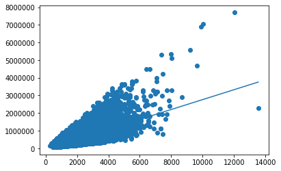

```python
### Trying a 1st degree polynomial
plot_lines(sales, 1)
```

```
['power_1', 'power_2']
coef [[6.79940947e+01 3.85812609e-02]]
intercept [199222.27930549]
```

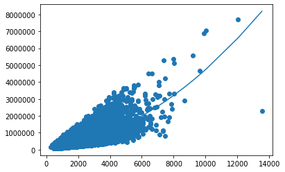

```python
### Trying a 2nd degree polynomial
plot_lines(sales, 2)
```

```
['power_1', 'power_2', 'power_3']
coef [[-9.01819864e+01  8.70465089e-02 -3.84055260e-06]]
intercept [336819.74822121]
```

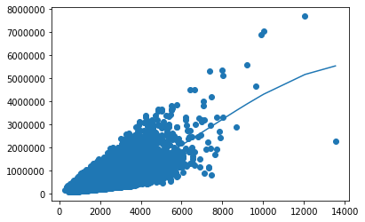

```python
### Trying a 3rd degree polynomial
plot_lines(sales, 3)
```

```
['power_1', 'power_2', 'power_3', 'power_4', 'power_5', 'power_6', 'power_7', 'power_8', 'power_9', 'power_10', 'power_11', 'power_12', 'power_13', 'power_14', 'power_15']
coef [[ 4.56404164e-91  6.91712192e-51 -5.84649119e-56  2.78197775e-88
   1.19863929e-74  2.68575522e-71  2.26147568e-67  1.85900299e-63
   1.47144116e-59  1.09771012e-55  7.43509038e-52  4.23015578e-48
   1.61618577e-44 -2.49283826e-48  9.59718336e-53]]
intercept [537116.32963771]
```

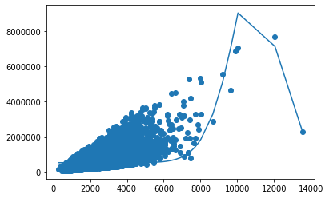

```python
### Trying a 15th degree polynomial
plot_lines(sales, 15)
```

What do you think of the 15th degree polynomial? Do you think this is appropriate? If we were to change the data do you think you'd get pretty much the same curve? Let's take a look.